# Project_2

## 2.1 Устранение мультиколлениарности

Итак, займемся улучшением полной модели, для начала проверив модель на мультиколлениарность предикторов с использованием VIF. Будем исключать из модели те предикторы, значение VIF для которых больше 2.

```r
mod_full <- lm(medv ~ ., data = data_scale)
vif(mod_full)
```

```
##              GVIF Df GVIF^(1/(2*Df))
## crim     1.811867  1        1.346056
## zn       2.496184  1        1.579932
## indus    4.370471  1        2.090567
## chas     1.101843  1        1.049687
## nox      4.672906  1        2.161691
## rm       2.007593  1        1.416896
## age      3.177556  1        1.782570
## dis      4.143583  1        2.035579
## rad     18.783126  8        1.201187
## tax      9.876853  1        3.142746
## ptratio  2.242683  1        1.497559
## black    1.352516  1        1.162977
## lstat    2.997620  1        1.731364
```

Видим, что из-за существования факторной переменной rad с таким большим количеством градаций фактора, стандартная функция считает вместо показателя VIF показатель GVIF - generalized VIF, являющийся рекоммендованным для работы с показателями с более чем двумя уровнями. Однако, судя по всему, показатель тем не менее обрабатывается не совсем корректно и принимает значение больше 10. В любом случае, GVIF равный 18 для предиктора rad является значимым поводом удалить этот предиктор из дальнейшей модели. Тем более, что если бы мы не принимали rad в качестве фактора, а работали с ним как с численной переменной, то значение обычного VIF для него тем не менее превышало бы 2.

```r
data_scale$chas <- as.numeric(data_scale$chas)
data_scale$rad <- as.numeric(data_scale$rad)
mod_full_without_factors <- lm(medv ~ ., data = data_scale)
vif(mod_full_without_factors)
```

```
##     crim       zn    indus     chas      nox       rm      age      dis
## 1.689328 2.398052 3.951825 1.073809 4.356842 1.915202 3.084780 3.964499
##      rad      tax  ptratio    black    lstat
## 3.132715 5.694625 1.735008 1.342652 2.938392
```

```r
data$chas <- as.factor(data$chas)
```

Значит, в любом случае удаление rad было бы корректно - поэтому удалим его из нашей модели первым чтобы в дальнейшем работать с более понятными показателями VIF.

```r
mod_2 <- update(mod_scale, .~. - rad)
vif(mod_2)
```

```
##     crim       zn    indus     chas      nox       rm      age      dis
## 1.664471 2.273018 3.682265 1.061561 4.304929 1.885425 3.083009 3.954951
##      tax  ptratio    black    lstat
## 3.415289 1.734873 1.341459 2.937752
```

Теперь переменную nox:

```r
mod_3 <- update(mod_2, .~. - nox)
vif(mod_3)
```

```
##     crim       zn    indus     chas       rm      age      dis      tax
## 1.663613 2.266956 3.477127 1.058946 1.875477 2.878244 3.628870 3.095110
##  ptratio    black    lstat
## 1.566568 1.331479 2.921385
```

Далее без отдельных комментариев будем удалять предикторы из модели, пока не останутся только предикторы с показателями не превышающими 2.

```r
mod_4 <- update(mod_3, .~. - dis)
vif(mod_4)
```

```
##     crim       zn    indus     chas       rm      age      tax  ptratio
## 1.637882 1.826807 3.155735 1.057774 1.847368 2.430656 3.073277 1.504126
##    black    lstat
## 1.331457 2.920516
```

```r
mod_5 <- update(mod_4, .~. - indus)
vif(mod_5)
```

```
##     crim       zn     chas       rm      age      tax  ptratio    black
## 1.622496 1.695271 1.045869 1.813320 2.291640 2.209662 1.499542 1.329512
##    lstat
## 2.897706
```

```r
mod_6 <- update(mod_5, .~. - lstat)
vif(mod_6)
```

```
##     crim       zn     chas       rm      age      tax  ptratio    black
## 1.581361 1.692884 1.043834 1.222973 1.861441 2.183730 1.498101 1.291187
```

```r
mod_7 <- update(mod_6, .~. - tax)
vif(mod_7)
```

```
##     crim       zn     chas       rm      age  ptratio    black
## 1.342583 1.680416 1.043732 1.216701 1.668190 1.345528 1.209887
```

Можно теперь оценить, какой вид имеет график для данных, из которых исключены предикторы, дающие мультиколлениарность.

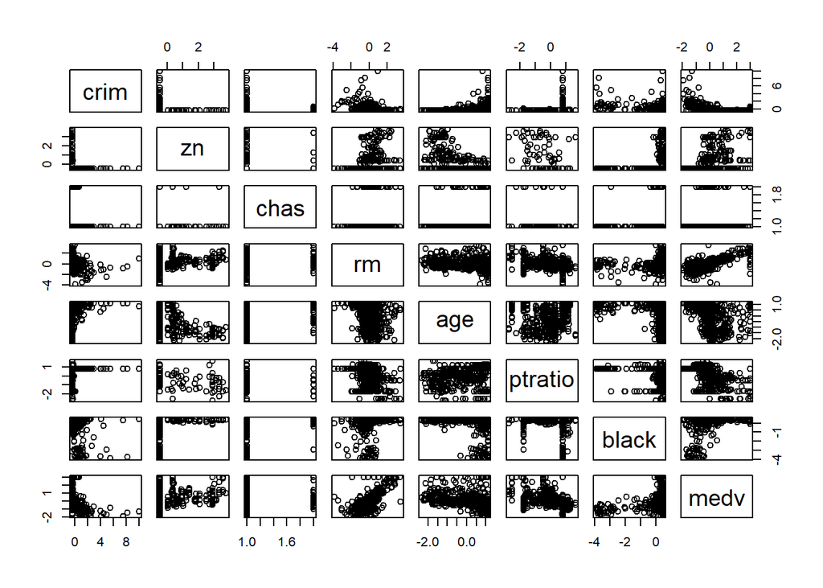

```r
data_without_multi <- data_scale[,-c(3, 5, 8, 9, 10, 13)]
plot(data_without_multi)
```

### 2.1.1 Диагностика

Собственно, можно оценить, стала ли модель лучше по интересующим нас параметрам. Для этого проведем частичный аналогичный первой части анализ.

```r
summary(mod_7)
```

```
##
## Call:
## lm(formula = medv ~ crim + zn + chas + rm + age + ptratio + black,
##     data = data_scale)
##
## Residuals:
##     Min      1Q  Median      3Q     Max
## -2.1032 -0.3210 -0.0818  0.1834  4.3208
##
## Coefficients:
##              Estimate Std. Error t value Pr(>|t|)
## (Intercept) -0.409235   0.119210  -3.433 0.000647 ***
## crim        -0.100784   0.031286  -3.221 0.001359 **
## zn          -0.007876   0.035002  -0.225 0.822060
## chas         0.382759   0.108606   3.524 0.000464 ***
## rm           0.539676   0.029783  18.120  < 2e-16 ***
## age         -0.126828   0.034874  -3.637 0.000305 ***
## ptratio     -0.218429   0.031321  -6.974 9.84e-12 ***
## black        0.148738   0.029700   5.008 7.65e-07 ***
## ---
## Signif. codes:  0 '***' 0.001 '**' 0.01 '*' 0.05 '.' 0.1 ' ' 1
##
## Residual standard error: 0.6068 on 498 degrees of freedom
## Multiple R-squared:  0.6369, Adjusted R-squared:  0.6318
## F-statistic: 124.8 on 7 and 498 DF,  p-value: < 2.2e-16
```

Сразу можно обратить внимание, что у модели только ухудшился показатель улучшенного R-квадрат, так что с ней точно стоит пробовать проводить дальнейшие улучшения.

Так же можно построить график остатков:

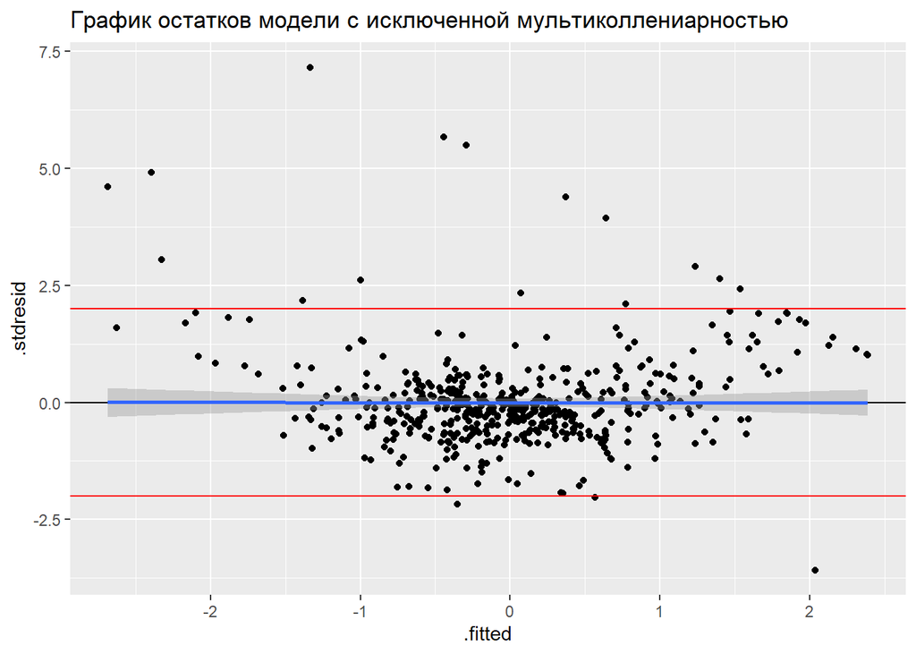

```r
mod_7_diag <- data.frame(fortify(mod_7), data_scale[,c(3, 5, 8, 9, 10, 13)])

gg_resid <- ggplot(data = mod_7_diag, aes(x = .fitted, y = .stdresid)) +
  geom_point() +
  geom_hline(yintercept = 0)+
  geom_smooth(method = "lm") +
  geom_hline(yintercept = 2, color = "red") +
  geom_hline(yintercept = -2, color = "red") +
  ggtitle("График остатков модели с исключенной мультиколлениарностью")

gg_resid
```

И график расстояний Кука:

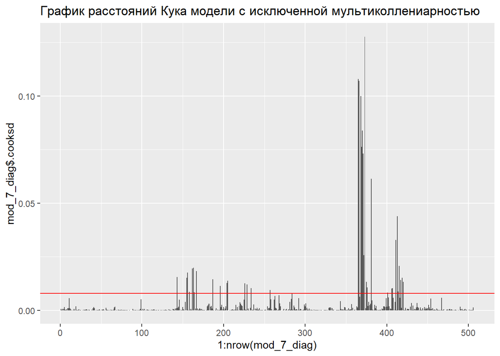

```r
ggplot(, aes(x = 1:nrow(mod_7_diag), y = mod_7_diag$.cooksd)) +
  geom_bar(stat = "identity")+
  geom_hline(yintercept = 4/nrow(data_without_multi), color = "red")+
  ggtitle("График расстояний Кука модели с исключенной мультиколлениарностью")
```

А так же график qq-plot.

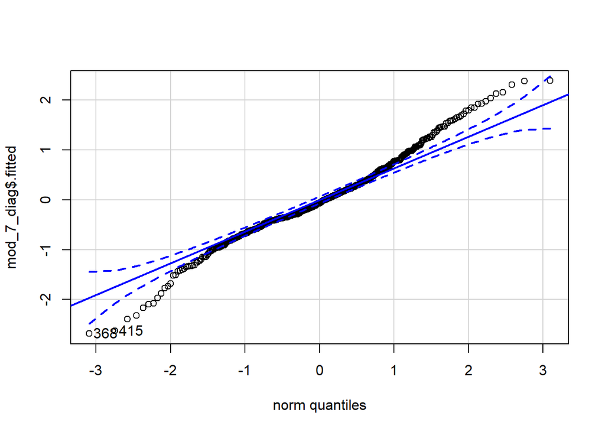

```
## [1] 368 415
```

```r
qqPlot(mod_7_diag$.fitted)
```

Несмотря на благие намерения исключения мультиколлениарности, модель стала хуже по параметру улучшенного R-квадрата, а графики остатков и расстояний кука значимо (можно увидеть, что число точек, выбивающихся за 2 стандартных отклонения немного уменьшилось, а пиков на графике расстояний Кука стало немного меньше) не изменились. График qq-plot же как будто стал еще хуже, потому что еще большее число точек и в конце, и в начале стали выбиваться за значения, соответствовавшие бы нормальному распределению. Будем дальше улучшать модель путем подбора исключительно значимых параметров.

## 2.2 Пошаговый отбор предикторов по значимости

Будем последовательно удалять предикторы, если при сравнивания модели без предиктора и более полной модели на основании частного F-теста выясняется, что предиктор незначимо объясняет изменчивость зависимой переменной, то такой предиктор мы будем удалять.

```r
drop1(mod_7, test = "F")
```

```
## Single term deletions
##
## Model:
## medv ~ crim + zn + chas + rm + age + ptratio + black
##         Df Sum of Sq    RSS     AIC  F value    Pr(>F)
## <none>               183.35 -497.65
## crim     1     3.821 187.17 -489.22  10.3772 0.0013592 **
## zn       1     0.019 183.37 -499.60   0.0506 0.8220598
## chas     1     4.573 187.93 -487.19  12.4206 0.0004638 ***
## rm       1   120.885 304.24 -243.42 328.3350 < 2.2e-16 ***
## age      1     4.869 188.22 -486.39  13.2258 0.0003049 ***
## ptratio  1    17.907 201.26 -452.50  48.6365 9.843e-12 ***
## black    1     9.234 192.59 -474.79  25.0805 7.646e-07 ***
## ---
## Signif. codes:  0 '***' 0.001 '**' 0.01 '*' 0.05 '.' 0.1 ' ' 1
```

```r
mod_8 <- update(mod_7, .~. - zn)
drop1(mod_8, test = "F")
```

```
## Single term deletions
##
## Model:
## medv ~ crim + chas + rm + age + ptratio + black
##         Df Sum of Sq    RSS     AIC F value    Pr(>F)
## <none>               183.37 -499.60
## crim     1     3.892 187.26 -490.98  10.591 0.0012133 **
## chas     1     4.611 187.98 -489.04  12.546 0.0004342 ***
## rm       1   123.107 306.48 -241.70 335.006 < 2.2e-16 ***
## age      1     6.083 189.45 -485.09  16.553 5.498e-05 ***
## ptratio  1    18.978 202.35 -451.77  51.644 2.440e-12 ***
## black    1     9.225 192.59 -476.77  25.103 7.559e-07 ***
## ---
## Signif. codes:  0 '***' 0.001 '**' 0.01 '*' 0.05 '.' 0.1 ' ' 1
```

Увидим, что нам пришлось исключить только 1 предиктор zn. Просмотрим, объясняет ли теперь модель изменчивость зависимой переменной лучшим образом.

### 2.2.1 Диагностика

```r
summary(mod_8)
```

```
##
## Call:
## lm(formula = medv ~ crim + chas + rm + age + ptratio + black,
##     data = data_scale)
##
## Residuals:
##     Min      1Q  Median      3Q     Max
## -2.1005 -0.3188 -0.0811  0.1863  4.3171
##
## Coefficients:
##             Estimate Std. Error t value Pr(>|t|)
## (Intercept) -0.41046    0.11897  -3.450 0.000608 ***
## crim        -0.10137    0.03115  -3.254 0.001213 **
## chas         0.38390    0.10838   3.542 0.000434 ***
## rm           0.53869    0.02943  18.303  < 2e-16 ***
## age         -0.12292    0.03021  -4.069 5.50e-05 ***
## ptratio     -0.21653    0.03013  -7.186 2.44e-12 ***
## black        0.14865    0.02967   5.010 7.56e-07 ***
## ---
## Signif. codes:  0 '***' 0.001 '**' 0.01 '*' 0.05 '.' 0.1 ' ' 1
##
## Residual standard error: 0.6062 on 499 degrees of freedom
## Multiple R-squared:  0.6369, Adjusted R-squared:  0.6325
## F-statistic: 145.9 on 6 and 499 DF,  p-value: < 2.2e-16
```

Улучшенный R-квадрат стал чуть лучше, но все еще хуже, чем у полной модели, так что наши преобразования однозначно не закончены.

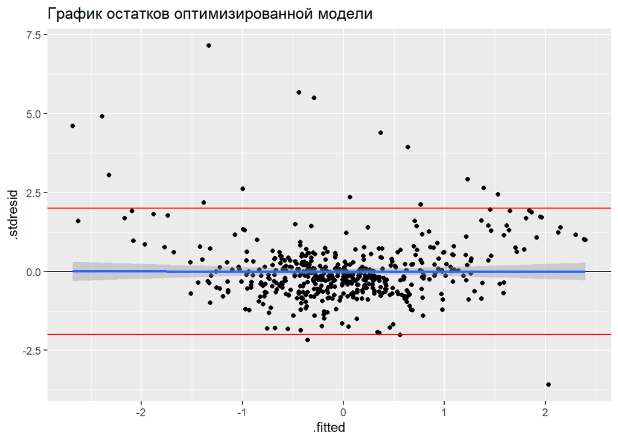

```r
mod_8_diag <- data.frame(fortify(mod_8), data_scale[,c(2, 3, 5, 8, 9, 10, 13)])

gg_resid <- ggplot(data = mod_8_diag, aes(x = .fitted, y = .stdresid)) +
  geom_point() +
  geom_hline(yintercept = 0)+
  geom_smooth(method = "lm") +
  geom_hline(yintercept = 2, color = "red") +
  geom_hline(yintercept = -2, color = "red") +
  ggtitle("График остатков оптимизированной модели")

gg_resid
```

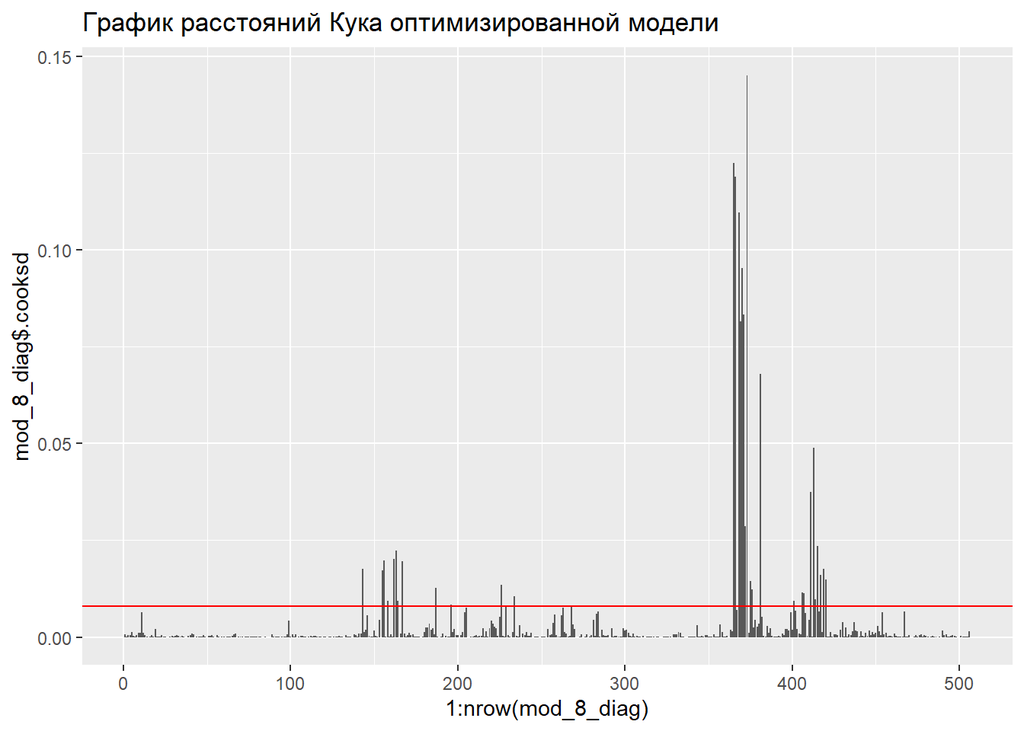

```r
ggplot(, aes(x = 1:nrow(mod_8_diag), y = mod_8_diag$.cooksd)) +
  geom_bar(stat = "identity")+
  geom_hline(yintercept = 4/nrow(data_scale), color = "red")+
  ggtitle("График расстояний Кука оптимизированной модели")
```

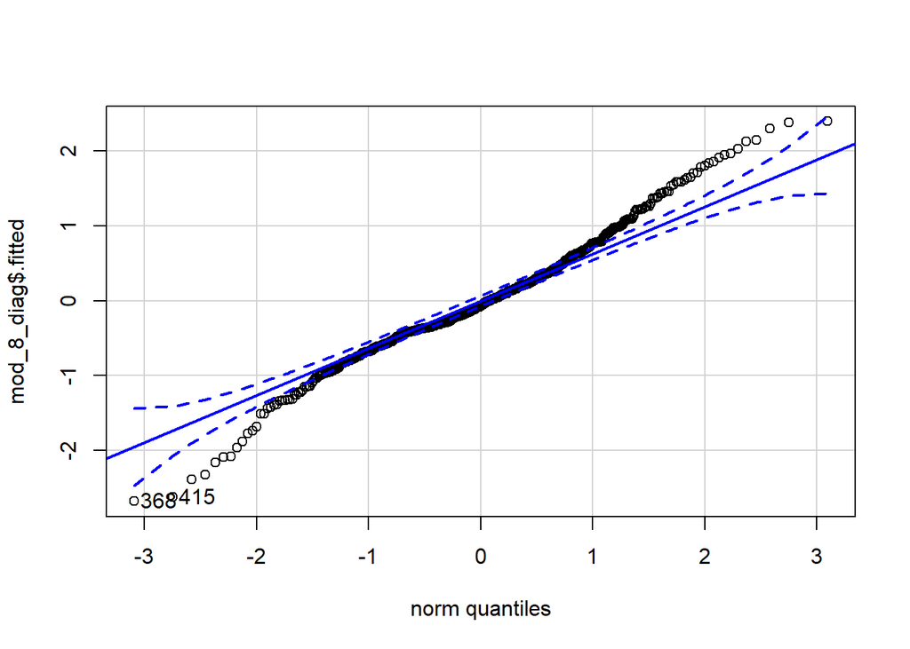

```
## [1] 368 415
```

```r
qqPlot(mod_8_diag$.fitted)
```

На вид, устранение предикторов, дававших мультиколлениарность, а так же незначимых предикторов, не исправило ни один из недостатков нашей модели, и в принципе мы добились только ухудшения в нашей цели объяснения изменчивости зависимой переменной. То есть наша модель сейчас:

- все еще обладает некоторой степенью нелинейности;
- распределения значений предикторов не являются нормальными;
- имеются влиятельные наблюдения;

## 2.3 Коррекция оптимальной модели

Наша проблема может быть связана с тем, что мы исключили слишком много предикторов на стадии исключения предикторов, дающих мультиколлениарность, то есть сильно коррелировавших с другими предикторами. В ходе этого процесса мы могли потерять какие-то важные зависимости, дающие большой вклад в изменчивость независимой переменной. Для определения этого построим диагностические графики с учетом тех предикторов, которые мы выкинули на стадии отбора по VIF:

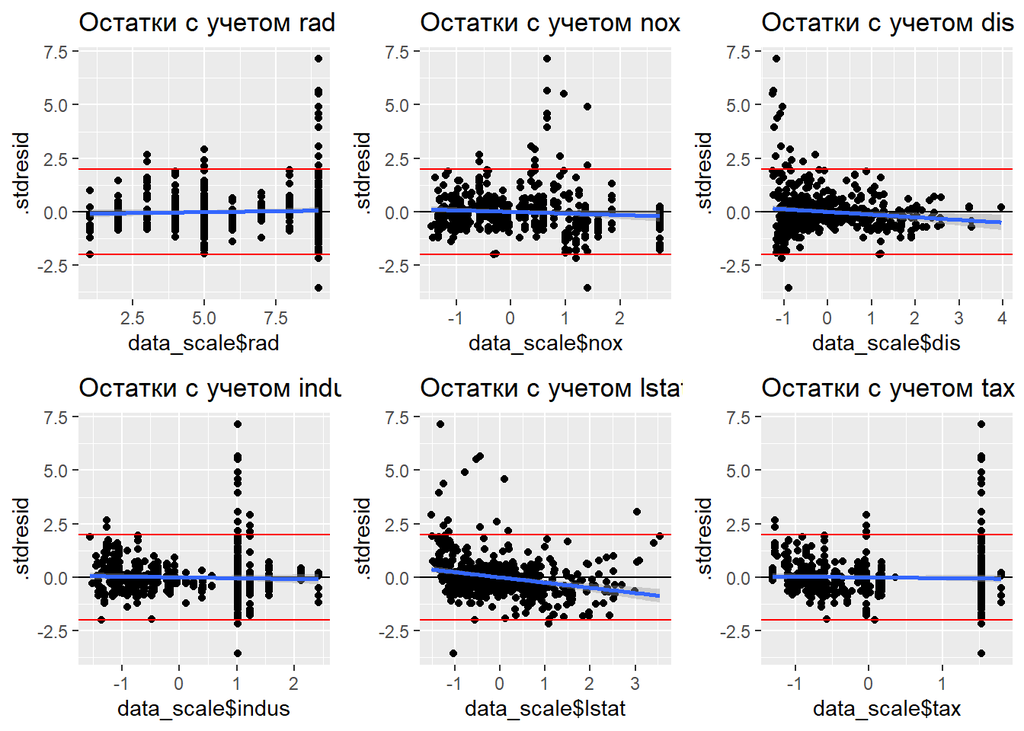

```r
res_1 <- gg_resid + aes(x = data_scale$rad) + ggtitle("Остатки с учетом rad")
res_2 <- gg_resid + aes(x = data_scale$nox) + ggtitle("Остатки с учетом nox")
res_3 <- gg_resid + aes(x = data_scale$dis) + ggtitle("Остатки с учетом dis")
res_4 <- gg_resid + aes(x = data_scale$indus) + ggtitle("Остатки с учетом indus")
res_5 <- gg_resid + aes(x = data_scale$lstat) + ggtitle("Остатки с учетом lstat")
res_6 <- gg_resid + aes(x = data_scale$tax) + ggtitle("Остатки с учетом tax")
grid.arrange(res_1, res_2, res_3, res_4,res_5, res_6,nrow = 2)
```

Увидим, что мы явно могли потерять зависимость предсказываемой переменной от параметров dis и lstat. Попробуем вернуть эти предикторы в оптимальную модель, несмотря на их вклад в мультиколлениарность, так как из-за этого скорее всего и падает улучшенный R-квадрат.

```r
mod_8_1 <- update(mod_8, .~. + dis + lstat)
summary(mod_8_1)
```

```
##
## Call:
## lm(formula = medv ~ crim + chas + rm + age + ptratio + black +
##     dis + lstat, data = data_scale)
##
## Residuals:
##      Min       1Q   Median       3Q      Max
## -1.98543 -0.30674 -0.08324  0.16784  3.13714
##
## Coefficients:
##             Estimate Std. Error t value Pr(>|t|)
## (Intercept) -0.32208    0.10657  -3.022 0.002638 **
## crim        -0.05782    0.02878  -2.009 0.045049 *
## chas         0.30124    0.09710   3.102 0.002030 **
## rm           0.35038    0.03206  10.930  < 2e-16 ***
## age         -0.08197    0.04019  -2.040 0.041918 *
## ptratio     -0.20286    0.02693  -7.532 2.37e-13 ***
## black        0.10397    0.02711   3.836 0.000141 ***
## dis         -0.18398    0.03715  -4.952 1.01e-06 ***
## lstat       -0.42025    0.04069 -10.328  < 2e-16 ***
## ---
## Signif. codes:  0 '***' 0.001 '**' 0.01 '*' 0.05 '.' 0.1 ' ' 1
##
## Residual standard error: 0.5409 on 497 degrees of freedom
## Multiple R-squared:  0.7121, Adjusted R-squared:  0.7075
## F-statistic: 153.7 on 8 and 497 DF,  p-value: < 2.2e-16
```

Действительно, нам удалось значительно поднять параметр улучшенного R-квадрат путем возвращения предикторов, дающих мультиколлениарность. Посмотрим, не стали ли какие-то предикторы теперь так же незначимыми и уберем их в случае обнаружения.

```r
drop1(mod_8_1, test = "F")
```

```
## Single term deletions
##
## Model:
## medv ~ crim + chas + rm + age + ptratio + black + dis + lstat
##         Df Sum of Sq    RSS     AIC  F value    Pr(>F)
## <none>               145.39 -613.05
## crim     1     1.181 146.57 -610.95   4.0372 0.0450489 *
## chas     1     2.815 148.20 -605.34   9.6242 0.0020295 **
## rm       1    34.947 180.34 -506.05 119.4652 < 2.2e-16 ***
## age      1     1.217 146.60 -610.83   4.1600 0.0419180 *
## ptratio  1    16.596 161.98 -560.35  56.7319 2.375e-13 ***
## black    1     4.304 149.69 -600.28  14.7137 0.0001412 ***
## dis      1     7.174 152.56 -590.67  24.5254 1.007e-06 ***
## lstat    1    31.207 176.59 -516.66 106.6775 < 2.2e-16 ***
## ---
## Signif. codes:  0 '***' 0.001 '**' 0.01 '*' 0.05 '.' 0.1 ' ' 1
```

Увидим, что ни один из предикторов не является незначимым, то есть p-value ни у одного не превышает 0.05. Однако, у двух предикторов - crim и age - уровни значимости близки к 0.05. Попробуем посмотреть на модели, где уберем эти предикторы - не станут ли они лучше?

```r
mod_8_1.1<-update(mod_8_1, .~. - crim)
summary(mod_8_1.1)
```

```
##
## Call:
## lm(formula = medv ~ chas + rm + age + ptratio + black + dis +
##     lstat, data = data_scale)
##
## Residuals:
##      Min       1Q   Median       3Q      Max
## -1.98077 -0.29654 -0.07042  0.17192  3.11151
##
## Coefficients:
##             Estimate Std. Error t value Pr(>|t|)
## (Intercept) -0.33057    0.10681  -3.095  0.00208 **
## chas         0.30919    0.09732   3.177  0.00158 **
## rm           0.34627    0.03209  10.791  < 2e-16 ***
## age         -0.07965    0.04029  -1.977  0.04863 *
## ptratio     -0.21019    0.02677  -7.853 2.52e-14 ***
## black        0.11647    0.02646   4.401 1.32e-05 ***
## dis         -0.17331    0.03688  -4.699 3.38e-06 ***
## lstat       -0.43778    0.03986 -10.982  < 2e-16 ***
## ---
## Signif. codes:  0 '***' 0.001 '**' 0.01 '*' 0.05 '.' 0.1 ' ' 1
##
## Residual standard error: 0.5425 on 498 degrees of freedom
## Multiple R-squared:  0.7098, Adjusted R-squared:  0.7057
## F-statistic:   174 on 7 and 498 DF,  p-value: < 2.2e-16
```

```r
mod_8_1.2<-update(mod_8_1, .~. - age)
summary(mod_8_1.2)
```

```
##
## Call:
## lm(formula = medv ~ crim + chas + rm + ptratio + black + dis +
##     lstat, data = data_scale)
##
## Residuals:
##     Min      1Q  Median      3Q     Max
## -1.9670 -0.3052 -0.0819  0.1647  3.0408
##
## Coefficients:
##             Estimate Std. Error t value Pr(>|t|)
## (Intercept) -0.30766    0.10667  -2.884 0.004093 **
## crim        -0.05613    0.02886  -1.945 0.052299 .
## chas         0.28776    0.09718   2.961 0.003213 **
## rm           0.34020    0.03177  10.710  < 2e-16 ***
## ptratio     -0.20596    0.02698  -7.635 1.16e-13 ***
## black        0.10226    0.02718   3.763 0.000188 ***
## dis         -0.13668    0.02912  -4.695 3.46e-06 ***
## lstat       -0.45278    0.03755 -12.058  < 2e-16 ***
## ---
## Signif. codes:  0 '***' 0.001 '**' 0.01 '*' 0.05 '.' 0.1 ' ' 1
##
## Residual standard error: 0.5426 on 498 degrees of freedom
## Multiple R-squared:  0.7097, Adjusted R-squared:  0.7056
## F-statistic: 173.9 on 7 and 498 DF,  p-value: < 2.2e-16
```

```r
mod_8_1.3<-update(mod_8_1, .~. - age - crim)
summary(mod_8_1.3)
```

```
##
## Call:
## lm(formula = medv ~ chas + rm + ptratio + black + dis + lstat,
##     data = data_scale)
##
## Residuals:
##      Min       1Q   Median       3Q      Max
## -1.96300 -0.30133 -0.08077  0.17864  3.01851
##
## Coefficients:
##             Estimate Std. Error t value Pr(>|t|)
## (Intercept) -0.31631    0.10687  -2.960  0.00323 **
## chas         0.29585    0.09737   3.039  0.00250 **
## rm           0.33648    0.03180  10.582  < 2e-16 ***
## ptratio     -0.21300    0.02681  -7.946 1.29e-14 ***
## black        0.11445    0.02652   4.316 1.92e-05 ***
## dis         -0.12762    0.02882  -4.428 1.17e-05 ***
## lstat       -0.46893    0.03672 -12.769  < 2e-16 ***
## ---
## Signif. codes:  0 '***' 0.001 '**' 0.01 '*' 0.05 '.' 0.1 ' ' 1
##
## Residual standard error: 0.5441 on 499 degrees of freedom
## Multiple R-squared:  0.7075, Adjusted R-squared:  0.704
## F-statistic: 201.2 on 6 and 499 DF,  p-value: < 2.2e-16
```

В каждой из таких моделей параметр R-квадрат падает, хоть и не сильно, однако видимых причин исключить предикторы age и crim не обнаружилось - формально они проходят установленное значение p-value, а модель как минимум не улучшается. Посмотрим, однако, ради интереса, на графики остатков и расстояний Кука для данных моделей.

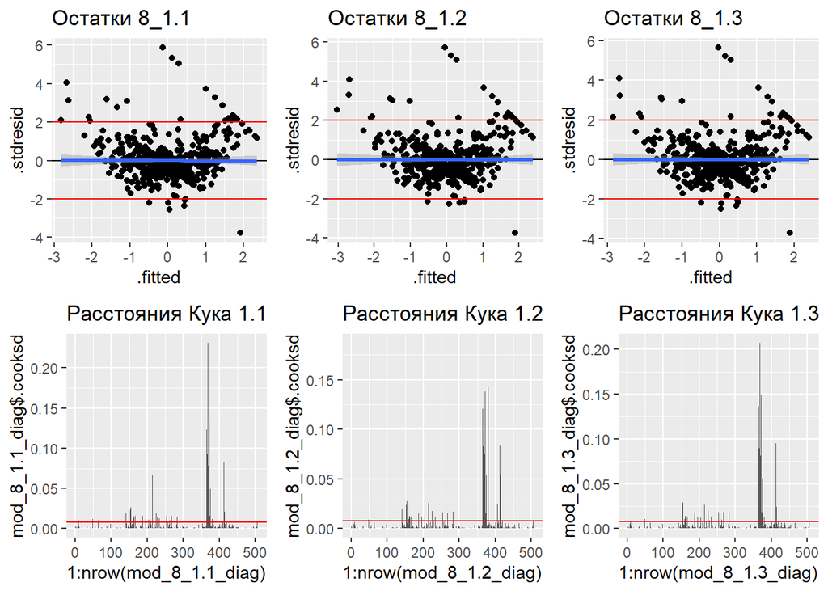

```r
mod_8_1.1_diag <- data.frame(fortify(mod_8_1.1), data_scale[,c(1, 2, 3, 5, 9, 10)])
mod_8_1.2_diag <- data.frame(fortify(mod_8_1.2), data_scale[,c(2, 3, 5, 7, 9, 10)])
mod_8_1.3_diag <- data.frame(fortify(mod_8_1.3), data_scale[,c(1, 2, 3, 5, 7, 9, 10)])

gg_resid_8_1.1 <- ggplot(data = mod_8_1.1_diag, aes(x = .fitted, y = .stdresid)) +
  geom_point() +
  geom_hline(yintercept = 0)+
  geom_smooth(method = "lm") +
  geom_hline(yintercept = 2, color = "red") +
  geom_hline(yintercept = -2, color = "red") +
  ggtitle("Остатки 8_1.1")

gg_resid_8_1.2 <- ggplot(data = mod_8_1.2_diag, aes(x = .fitted, y = .stdresid)) +
  geom_point() +
  geom_hline(yintercept = 0)+
  geom_smooth(method = "lm") +
  geom_hline(yintercept = 2, color = "red") +
  geom_hline(yintercept = -2, color = "red") +
  ggtitle("Остатки 8_1.2")

gg_resid_8_1.3 <- ggplot(data = mod_8_1.3_diag, aes(x = .fitted, y = .stdresid)) +
  geom_point() +
  geom_hline(yintercept = 0)+
  geom_smooth(method = "lm") +
  geom_hline(yintercept = 2, color = "red") +
  geom_hline(yintercept = -2, color = "red") +
  ggtitle("Остатки 8_1.3")

cook_8_1.1 <- ggplot(, aes(x = 1:nrow(mod_8_1.1_diag), y = mod_8_1.1_diag$.cooksd)) +
  geom_bar(stat = "identity")+
  geom_hline(yintercept = 4/nrow(data_scale), color = "red")+
  ggtitle("Расстояния Кука 1.1")

cook_8_1.2 <- ggplot(, aes(x = 1:nrow(mod_8_1.2_diag), y = mod_8_1.2_diag$.cooksd)) +
  geom_bar(stat = "identity")+
  geom_hline(yintercept = 4/nrow(data_scale), color = "red")+
  ggtitle("Расстояния Кука 1.2")

cook_8_1.3 <- ggplot(, aes(x = 1:nrow(mod_8_1.3_diag), y = mod_8_1.3_diag$.cooksd)) +
  geom_bar(stat = "identity")+
  geom_hline(yintercept = 4/nrow(data_scale), color = "red")+
  ggtitle("Расстояния Кука 1.3")

grid.arrange(gg_resid_8_1.1, gg_resid_8_1.2, gg_resid_8_1.3, cook_8_1.1, cook_8_1.2, cook_8_1.3,nrow = 2)
```

Для окончательной диагностики построим так же график qq-plot для нашей принятой за финальную модели:

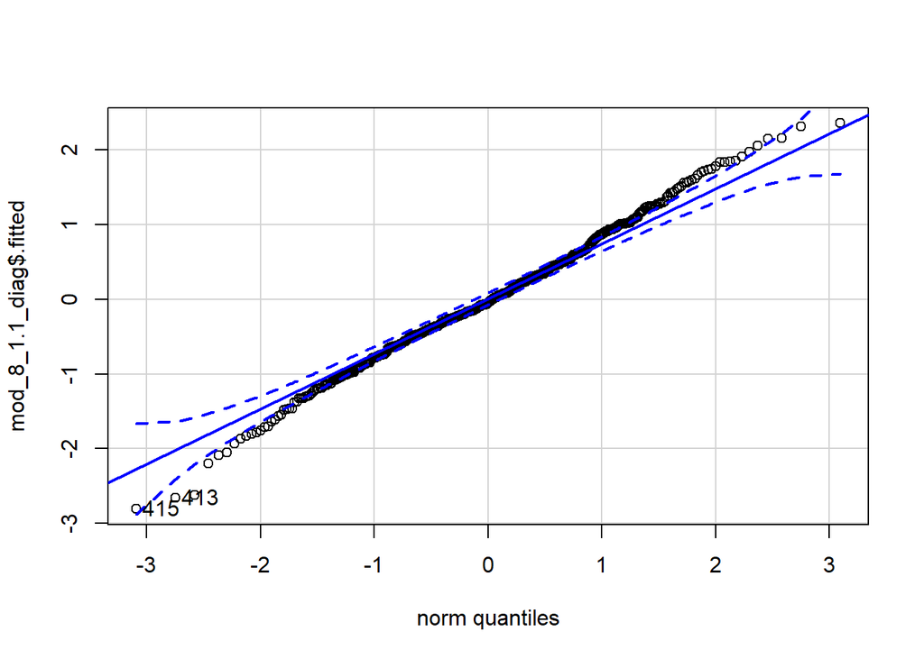

```
## [1] 415 413
```

```r
qqPlot(mod_8_1.1_diag$.fitted)
```

Нормальность у модели не стала значительно лучше, чем у полной модели, однако это распределение однозначно выглядит лучше, чем у модели, бывшей финальной до данного этапа - до возвращения предикторов dis и lstat и исключения crim. Проверим так же модель на наличие автокорреляций.

```r
durbinWatsonTest(mod_8_1.1)
```

```
##  lag Autocorrelation D-W Statistic p-value
##    1        0.482367      1.021699       0
##  Alternative hypothesis: rho != 0
```

Значение критерия Дарбина-Уотсона все еще довольно далеко от 2, но это объясняется тем, что мы возвращали предикторы, которые исключали по параметру VIF.

Итого, наша финальная модель, после всех доступных нам улучшений:

- проще, чем изначальная модель, так как зависит от меньшего числа переменных;
- обладает более выраженной нормальностью относительно полной модели;
- не удалось добиться линейности данных;
- обладает лучшей ситуацией с влиятельными наблюдениями;
- параметр улучшенный R-квадрат немного уменьшился, но значимо не изменился;
- нам пришлось оставить предикторы, дающие мультиколлениарность, чтобы не убирать важные зависимости для зависимой переменной.

## 2.4 Итоговая модель и ее предсказания

Посмотрим на нашу итоговую модель и сделаем по ней выводы. Итак, вот таким образом выглядит наш ответ для заказчика.

```r
summary(mod_8_1.1)
```

```
##
## Call:
## lm(formula = medv ~ chas + rm + age + ptratio + black + dis +
##     lstat, data = data_scale)
##
## Residuals:
##      Min       1Q   Median       3Q      Max
## -1.98077 -0.29654 -0.07042  0.17192  3.11151
##
## Coefficients:
##             Estimate Std. Error t value Pr(>|t|)
## (Intercept) -0.33057    0.10681  -3.095  0.00208 **
## chas         0.30919    0.09732   3.177  0.00158 **
## rm           0.34627    0.03209  10.791  < 2e-16 ***
## age         -0.07965    0.04029  -1.977  0.04863 *
## ptratio     -0.21019    0.02677  -7.853 2.52e-14 ***
## black        0.11647    0.02646   4.401 1.32e-05 ***
## dis         -0.17331    0.03688  -4.699 3.38e-06 ***
## lstat       -0.43778    0.03986 -10.982  < 2e-16 ***
## ---
## Signif. codes:  0 '***' 0.001 '**' 0.01 '*' 0.05 '.' 0.1 ' ' 1
##
## Residual standard error: 0.5425 on 498 degrees of freedom
## Multiple R-squared:  0.7098, Adjusted R-squared:  0.7057
## F-statistic:   174 on 7 and 498 DF,  p-value: < 2.2e-16
```

Получившееся в итоге уравнение для зависимой переменной имеет вид:

$$medv = { 0.30919*chas + 0.34627*rm - 0.07965*age - 0.21019*plratio + 0.11647*black -0.17331*dis - 0.43778*lstat - 0.33057}$$
Осуществим, собственно, предсказание по “улучшенной” линейной модели. Аналогично первой части, будем ориентироваться на предиктор с самым большим значением коэффициента, то есть опять же lstat. Для этого сначала создадим тестовый датасет:

```r
MyData_for_8_1.1 <- data.frame(
     chas = data_scale$chas,
     rm = mean(data_scale$rm),
     age = mean(data_scale$age),
     dis = mean(data_scale$dis),
     ptratio = mean(data_scale$ptratio),
     black = mean(data_scale$black),
     lstat = seq(min(data_scale$lstat), max(data_scale$lstat),length.out = nrow(data_scale)))
Predictions_for_8_1.1 <- predict(mod_8_1.1, newdata = MyData_for_8_1.1,  interval = 'confidence')
data_predicted_adj <- data.frame(MyData_for_8_1.1, Predictions_for_8_1.1)
```

И затем построим график:

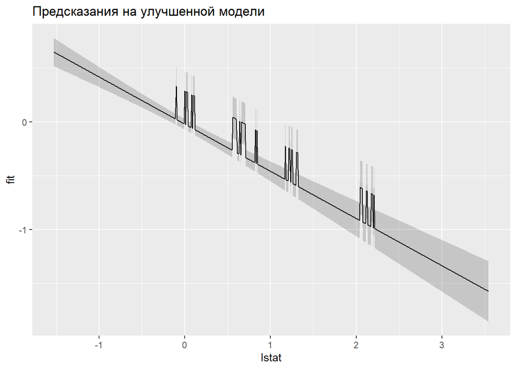

```r
Pl_predict_adj <- ggplot(data_predicted_adj, aes(x = lstat, y = fit)) +
  geom_ribbon(alpha = 0.2, aes(ymin = lwr, ymax = upr)) +
  geom_line() +
  ggtitle("Предсказания на улучшенной модели")
Pl_predict_adj
```

## 2.5 Выводы по данным и модели

Господин заказчик! К сожалению, качество поступивших на обработку данных не позволило построить достаточно качественную линейную модель для предсказания цены дома. Тем не менее, многодневная работа нашего агенства позволила построить линейную модель, обладающую некоторыми преимуществами по сравнению с полной моделью, так что мы можем дать Вам совет по поводу того, на каких именно аспектах стоит сосредоточиться, чтобы извлекать максимальную выгоду из операций с недвижимостью в славном Бостоне в наши тяжелые 70е года. Эта модель обладает относительно нормальным распределением для остатков, исключает большое число влиятельных наблюдений, а так же обладает постоянством дисперсии. Все эти успехи позволяют нам быть уверенными в том, что Вы не зря обратились именно к нам, а так же что наша работа будет соотвественно высоко оценена и оплачена Вами, а в дальнейшем мы сможем продолжить выгодное сотрудничество.

С Вашего позволения, креативный отдел нащего агенства предоставит Вам запрашиваемые данные в виде стихотворения:

```
Добрый день. Господин клиент
Чтобы денег побольше Вам обрести
Наше агенство дает инструмент
Для успеха на рынке недвижимости

Во избежании всяких там казусов
И выгод как можно больше дальнейших
Ищите район, где низкого статуса
Процент населения как можно меньше
```